# Financial Mathematics 1 - Course Review

Instructor: Dr. Le Nhat Tan

# 1 Theory of Interest

## 1.2 Investment Analysis

Consider an investment of outlay (required capital) $C_0$ that generates a stream of cashflows (without reinvestment) $C_1,...,C_n$ in the next $n$ year. Assume that other similar investments have the annually compounded interest rate $r.$

1. Its **present value** is given by
   $$\textrm{PV}=\sum_{i=1}^n\frac{C_i}{(1+r)^i}$$
   while its **net present value** is given by
   $$\textrm{NPV}=\textrm{PV}-C_0.$$
   We should invest in this investment if and only if $\textrm{NPV}>0.$
2. Its **internal rate of return** $r_{\textrm{IRR}}$ should solves the equation
   $$C_0=\sum_{i=1}^n\frac{C_i}{(1+r_{\textrm{IRR}})^i}.$$
   We should invest in this investment if and only if $r_{\textrm{IRR}}>r.$
3. In comparison between multiple investments, we should invest in the one having the highest IRR/NPV.

# 2 Fixed Income Analysis

## 2.1 Annuity - Perpetuity

**Annuity**, in general, is a series of periodic payment $$K$ made over $n$ next periods, with the corresponding interest rate $r$ compounded $m$ times per year. Assume that a year has $p$ periods, then the present value (before the occurrence of the first payment) of this annuity is given by
$$\textrm{PV}=\sum_{i=1}^n\frac{K}{\left(1+r/m\right)^{i\cdot
m/p}}$$
while its future value (at the occurrence of the last payment) is given by
$$\textrm{FV}=\textrm{PV}\cdot\left(1+\frac{r}{m}\right)^{n\cdot
m/p}=\sum_{i=1}^nK\cdot\left(1+\frac{r}{m}\right)^{(n-i)\cdot
m/p}.$$
If $n=\infty,$ then this annuity is called a **perpetuity** with the present value
$$\textrm{PV}=\sum_{i=1}^{\infty}\frac{K}{\left(1+r/m\right)^{i\cdot
m/p}}=\frac{K}{(1+r/m)^{m/p}-1}.$$

## 2.2 Loan Payment

Assume we admit an $n-$year mortgage of $$B$ with periodic payment $$P$ of $k$ times per year. The annual interest rate is $r,$ compounded $m$ times per year.

1. $B$ and $P$ must satisfy the equation
   $$B=\sum_{i=1}^{n\cdot
   k}\frac{P}{(1+r/m)^{i*m/k}}.$$
2. The $q^{\textrm{th}}$ **unpaid loan balance** is
   $$B_q=\sum_{i=1}^{n\cdot
   k-q}\frac{P}{(1+r/m)^{i*m/k}}$$
   which implies the $q^{\textrm{th}}$ **interest payment**
   $$I_q=B_{q-1}\cdot\left(\sqrt[k]{(1+r/m)^m}-1\right)$$
   and the $q^{\textrm{th}}$ **principal payment** $P-I_q.$

## 2.3 Bond Evaluation

Consider a **coupon bond** of $n$ years to maturity with coupon rate $c$ and face value $F.$ Assume coupon payments are made $p$ times annually.

1. If $c=0,$ then the bond is called a **zero-coupon bond.**
2. If the interest rate p.a. is $r$ compounded $k$ times annually, then the bond’s **price** is the present value of all its generated cashflows:
   $$P(r)=\sum_{i=1}^{p\cdot
   n}\frac{c\cdot F/p}{(1+r/k)^{i\cdot k/p}}+\frac{F}{(1+r/k)^{n\cdot
   k}}.$$
   If the interest rate p.a. is $r$ compounded continuously, the bond’s price is
   $$P(r)=\sum_{i=1}^{p\cdot
   n}\frac{c\cdot F/p}{e^{r\cdot i/p}}+\frac{F}{e^{r\cdot
   n}}.$$
3. Assume that the bond’s current price is $P_0,$ its **yield to maturity** $y$ is precisely the internal rate of return derived from considering an investment of buying that bond, i.e. $y$ solves the equation $P_0=P(y).$
4. Assume that the bond yield $y$ changes by a quantity $\Delta y,$ then we derive the corresponding **bond duration**
   $$D=\frac{P(y-\Delta y)-P(y+\Delta y)}{2\cdot
   P(y)\cdot\Delta y}$$
   which then can be used to estimate the change in price as
   $$\frac{P(y-\Delta
   y)-P(y)}{P(y)}\approx-\frac{P(y+\Delta y)-P(y)}{P(y)}\approx
   D\cdot\Delta y.$$
   We can also derive the corresponding **bond convexity**
   $$C=\frac{P(y+\Delta y)+P(y-\Delta y)-2\cdot
   P(y)}{P(y)\cdot(\Delta y)^2}$$
   which gives better estimations for price change as
   $$\frac{P(y-\Delta
   y)-P(y)}{P(y)}\approx D\cdot\Delta y+0.5\cdot C\cdot(\Delta
   y)^2.$$
   and
   $$\frac{P(y+\Delta
   y)-P(y)}{P(y)}\approx-D\cdot\Delta y+0.5\cdot C\cdot(\Delta
   y)^2.$$

# 3 Capital Allocation

1. Consider four investment projects as follows:

| Project | Expected Cashflow | Standard Deviation |
| --- | --- | --- |
| A | 4200 | 3894 |
| B | 7000 | 1449 |
| C | 70000 | 14491 |
| D | 7000 | 1183 |

The coefficient of variation of each project is given by
$$\left(\frac{3894}{4200},\frac{1449}{7000},\frac{14491}{70000},\frac{1183}{7000}\right)\approx(0.927,0.207,0.207,0.169)$$
so project $D$ is least risky and project $A$ is riskiest.

2. Consider a number of promising projects, which can either be chosen to invest or not, as follows:

| Project | 1 | 2 | 3 | 4 |
| --- | --- | --- | --- | --- |
| Outlay 1 | 90 | 80 | 50 | 20 |
| Outlay 2 | 58 | 80 | 100 | 64 |
| NPV | 150 | 200 | 100 | 100 |

If budgets of $200 and $250 is available for the first and second year, then the decision yielding the maximum profit is the solution to the ILP
$$\begin{matrix}\textrm{maximize}
& 150x_1+200x_2+100x_3+100x_4\\\textrm{subject to} &
90x_1+80x_2+50x_3+20x_4\leq200\\&
58x_1+80x_2+100x_3+64x_4\leq250\\&
x_i\in\left\{0,1\right\},i=\overline{1,4}\end{matrix}$$

```r
my.lp = make.lp(0, 4)
lp.control(my.lp, sense = 'max')
set.objfn(my.lp, c(150, 200, 100, 100))
add.constraint(my.lp, c(90, 80, 50, 20), '<=', 200)
add.constraint(my.lp, c(58, 80, 100, 64), '<=', 250)
set.type(my.lp, 1:4, 'binary') #integer
solve(my.lp)
get.objective(my.lp)
get.variables(my.lp)
```

3. Suppose that you own both a lake and a fishing boat, and have three seasons (each season is a year) to fish. Each season you decide either to fish or not to fish. If you do not fish, the population will double by the start of the next season. If you do fish, you will extract 70% of the population. The fish will reproduce, and the population of the next season will be the same as the current season. The initial population is 10 tons. Your profit is $1 per ton. The interest rate is constant at 25% p.a. To maximize the profit, which of those seasons should you fish?

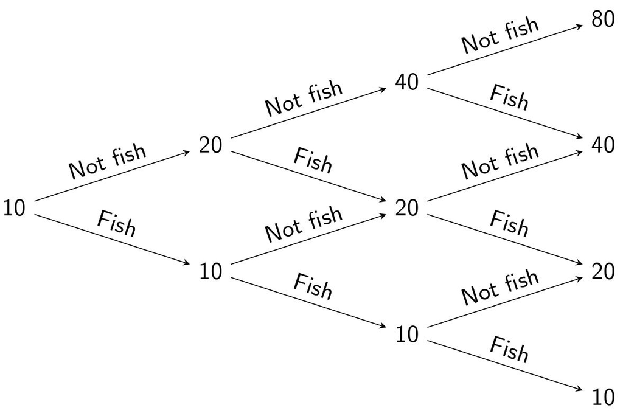

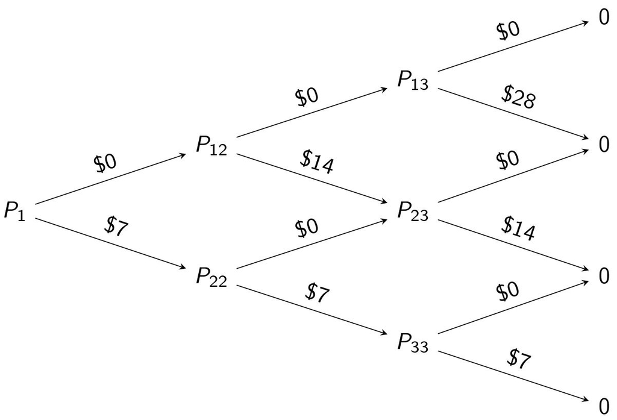

$$P_{13}=\max(0,28)=28,P_{23}=\max(0,14)=14,P_{33}=7$$
$$P_{12}=\max\left(\frac{P_{13}}{1+0.25},14+\frac{P_{23}}{1+0.25}\right)=25.2$$
$$P_{22}=\max\left(\frac{P_{23}}{1+0.25},7+\frac{P_{33}}{1+0.25}\right)=12.6$$
$$P_1=\max\left(\frac{P_{12}}{1+0.25},7+\frac{P_{22}}{1+0.25}\right)=20.16.$$
Thus the optimal profit is 20.16, and we should fish in seasons 2 and 3.

# 4 Portfolio Analysis

Suppose we invest $$X$ in $n$ assets of price $S_1,...,S_n$ with corresponding amount $X_1,...,X_n$ in the sense that
$$X=\sum_{i=1}^nX_i.$$

1. The **weight vector** of this **portfolio** is
   $$\omega=(\omega_1,...,\omega_n)=\left(\frac{X_1}{X},...,\frac{X_n}{X}\right).$$
2. Let $r_i$ be the (rate of) return on asset $i,$ then the portfolio return is
   $$r=\sum_{i=1}^nr_i\omega_i.$$
3. If $\omega=(\alpha,1-\alpha),$ i.e. there are two assets only, then with further assumptions that the assets have return volatilites $\sigma_1,\sigma_2$ and correlation $\rho_{12}$ we obtain the variance of portfolio return as
   $$\sigma^2=\alpha^2\cdot\sigma_1^2+(1-\alpha)^2\cdot\sigma_2^2+2\alpha(1-\alpha)\cdot\sigma_1\cdot\sigma_2\cdot\rho_{12}.$$
4. With the above assumption and short sell **is not permitted**, the portfolio of minimum variance is the optimal solution of the quadratic program
   $$\begin{matrix}\textrm{minimize} &
   -d^Tb+b^TDb/2\\\textrm{subject to} & A^Tb\geq
   b_0\end{matrix}$$
   where
   $$\omega=\begin{pmatrix}\alpha\\1-\alpha\end{pmatrix},b_0=\begin{pmatrix}1\\0\\0\end{pmatrix},d=\begin{pmatrix}0\\0\end{pmatrix},$$
   $$D=\begin{pmatrix}\sigma_1^2 &
   \rho_{12}\sigma_1\sigma_2\\\rho_{12}\sigma_1\sigma_2 &
   \sigma_2^2\end{pmatrix},A=\begin{pmatrix}1 & 1 & 0\\1 & 0
   & 1\end{pmatrix}.$$
   If short sell **is permitted**, we make the adjustments
   $$A=\begin{pmatrix}1 & 0 & 0\\1 & 0
   & 0\end{pmatrix}.$$
   An alternative approach is to determine the critical points of $\sigma^2,$ which should be considered as a function of $\alpha.$

```r
Dmat = matrix(c(0.04, 0.0108, 0.0108, 0.0324), 2, 2)
dvec = c(0, 0)
Amat = matrix(c(1, 1, 1, 0, 0, 1), 2, 3)
b0 = c(1, 0, 0)
n.eqs = 1 # no constraint is equality
result = solve.QP(2 * Dmat, dvec, Amat, bvec = b0, meq = n.eqs)
min_var_port = result$solution
```

5. If assets have return volatilites $\sigma_i$ and correlations $\rho_{ij},1\leq i<j\leq n,$ then the variance of portfolio return is
   $$\sigma_P^2=\sum_{i=1}^n\omega_i^2\sigma_i^2+\sum_{1\leq
   i<j\leq
   n}2\omega_i\omega_j\sigma_i\sigma_j\rho_{ij}.$$
6. The **minimum variance portfolio** is the solution to the nonlinear program
   $$\begin{matrix}
   \textrm{minimize} & \sigma_P^2\\
   \textrm{subject to} & \sum\omega_i=1\\
   & \omega_i\in\mathbb{R}
   \end{matrix}$$
   where the **efficient portfolio** of return $\alpha>0$ is the solution to the nonlinear program
   $$\begin{matrix}
   \textrm{minimize} & \sigma_P^2\\
   \textrm{subject to} & r_P=\alpha\\
   & \sum\omega_i=1\\
   & \omega_i\in\mathbb{R}
   \end{matrix}$$
   Note that if short sell is **not** permitted, the programs above become
   $$\begin{matrix}
   \textrm{minimize} & \sigma_P^2\\
   \textrm{subject to} & \sum\omega_i=1\\
   & \omega_i\geq0\\
   & \omega_i\in\mathbb{R}
   \end{matrix}$$
   and
   $$\begin{matrix}
   \textrm{minimize} & \sigma_P^2\\
   \textrm{subject to} & r_P=\alpha\\
   & \sum\omega_i=1\\
   & \omega_i\geq0\\
   & \omega_i\in\mathbb{R}
   \end{matrix}$$
7. **Karush$-$Kuhn$-$Tucker Theorem:** consider the program
   $$\begin{matrix}
   \textrm{minimize} & f(x)\\
   \textrm{subject to} & h_1(x)=...=h_m(x)=0\\
   & g_1(x),...,g_p(x)\leq0
   \end{matrix}$$
   and $x^*$ is a minimum point of this program. Its **Lagragian** is
   $$\mathcal{L}(x,\lambda,\mu)=f(x)+\sum_{i=1}^m\lambda_ih_i(x)+\sum_{j=1}^p\mu_jg_j(x)$$
   and there exist numbers $\lambda_i,\mu_j$ such that $\mu_j\geq0$ and
   $$\left\{\begin{matrix}
   \mathcal{L}_{x_k}=0,\forall k\\
   h_i(x)=0,\forall i\\
   \mu_jg_j(x)=0,\forall j
   \end{matrix}\right.$$

# 5 Forward Contract

## 5.1 No Dividend

Consider a $T-$year forward contract on an asset **paying no dividend** with current price $S_0,$ interest rate $r$ p.a. compounding annually. We set up a portfolio $V$ as follows:

1. Today $(t=0):$
- Borrow $S_0$ to buy $1$ asset.
- Enter the contract to sell $1$ asset (at maturity) for $K.$
- Additional fees: $0.$
- Contract value: $V_0=S_0-S_0+0=0.$
2. At maturity $(t=T):$
- Repay the loan with $S_0\cdot(1+r)^T.$
- Hand over $1$ asset and receive the delivery price $K.$
- Additional fees: $0.$
- Contract value: $V_T=-S_0\cdot(1+r)^T+K+0=K-S_0\cdot(1+r)^T.$
3. Under the assumption of no arbitrage, $V_T=0\Rightarrow K=S_0\cdot(1+r)^T.$
4. The delivery price is, therefore, $S_0\cdot(1+r)^T.$

Similarly, if $r$ compounds $n$ times p.a., then $K=S_0\cdot(1+r/n)^{Tn}.$ It implies that as $n\rightarrow\infty,$ i.e. $r$ compounds continuously,
$$K=\lim_{n\rightarrow\infty}S_0\cdot\left(1+\frac{r}{n}\right)^{Tn}=S_0\cdot
e^{rT}.$$

## 5.2 Discrete Dividend

Consider a $T-$year forward contract on an asset with current price $S_0,$ interest rate $r$ p.a. compounding annually. This asset **pays dividend discretely** at time $0<t_1<...<t_m<T$ with amount $c_1,...,c_m.$ We set up a portfolio $V$ as follows:

1. Today $(t=0):$
- Borrow $c_i\cdot(1+r)^{-t_i}$ for $t_i$ years, $i=\overline{1,m}.$
- Borrow $S_0-\sum c_i\cdot(1+r)^{-t_i}$ for $T$ years.
- Use the total money borrowed, $S_0,$ to buy $1$ asset.
- Enter the contract to sell $1$ asset (at maturity) for $K.$
- Additional fees: $0.$
- Contract value: $V_0=S_0-S_0+0=0.$
2. At each time $t=t_i,i=\overline{1,m}:$
- The loan $c_i\cdot(1+r)^{-t_i}$ becomes $c_i.$
- Repay this loan with the dividend $c_i$ paid.
3. At maturity $(t=T):$
- Repay the remaining loan with $\left(S_0-\sum c_i\cdot(1+r)^{-t_i}\right)\cdot(1+r)^T.$
- Hand over $1$ asset and receive the delivery price $K.$
- Additional fees: $0.$
- Contract value:
  $$\begin{align*}V_T
  &= -\left(S_0-\sum
  c_i\cdot(1+r)^{-t_i}\right)\cdot(1+r)^T+K+0\\&= K-\left(S_0-\sum
  c_i\cdot(1+r)^{-t_i}\right)\cdot(1+r)^T.\end{align*}.$$
4. Under the assumption of no arbitrage, $V_T=0\Rightarrow K=\left(S_0-\sum c_i\cdot(1+r)^{-t_i}\right)\cdot(1+r)^T.$
5. The delivery price is, therefore, $\left(S_0-\sum c_i\cdot(1+r)^{-t_i}\right)\cdot(1+r)^T.$

Similarly, if $r$ compounds $n$ times p.a., then $K=\left(S_0-\sum c_i\cdot(1+r/n)^{-t_in}\right)\cdot(1+r/n)^{Tn}.$ It implies that as $n\rightarrow\infty,$ i.e. $r$ compounds continuously,
$$K=\lim_{n\rightarrow\infty}\left(S_0-\sum_{i=1}^m
\frac{c_i}{(1+r/n)^{t_in}}\right)\cdot\left(1+\frac{r}{n}\right)^{Tn}=\left(S_0-\sum_{i=1}^m
\frac{c_i}{e^{rt_i}}\right)\cdot e^{rT}.$$

## 5.3 Continuous Dividend

Consider a $T-$year forward contract on an asset with current price $S_0,$ interest rate $r$ p.a. compounding annually. This asset **pays dividend continuously** with rate $\delta$ p.a., meaning that the dividend paid will be reinvested. We set up a portfolio $V$ as follows:

1. Today $(t=0):$
- Borrow $S_0\cdot e^{-\delta T}$ to buy $e^{-\delta T}$ asset.
- Enter the contract to sell $1$ asset (at maturity) for $K.$
- Additional fees: $0.$
- Contract value: $V_0=S_0\cdot e^{-\delta T}-S_0\cdot e^{-\delta T}+0=0.$
2. At maturity $(t=T):$
- Repay the loan with $S_0\cdot e^{-\delta T}\cdot(1+r)^T.$
- Hand over $1$ asset and receive the delivery price $K.$
- Additional fees: $0.$
- Contract value: $V_T=-S_0\cdot e^{-\delta T}\cdot(1+r)^T+K+0=K-S_0\cdot e^{-\delta T}\cdot(1+r)^T.$
3. Under the assumption of no arbitrage, $V_T=0\Rightarrow K=S_0\cdot e^{-\delta T}\cdot(1+r)^T.$
4. The delivery price is, therefore, $S_0\cdot e^{-\delta T}\cdot(1+r)^T.$

Similarly, if $r$ compounds $n$ times p.a., then $K=S_0\cdot e^{-\delta T}\cdot(1+r/n)^{Tn}.$ It implies that as $n\rightarrow\infty,$ i.e. $r$ compounds continuously,
$$K=\lim_{n\rightarrow\infty}S_0\cdot e^{-\delta
T}\cdot\left(1+\frac{r}{n}\right)^{Tn}=S_0\cdot
e^{(r-\delta)T}.$$

# 6 Future Contract

Assume an investor enters $C$ future contracts, each of size $S$ with the initial price $P_0,$ initial margin $I,$ maintenance margin $M.$ Then the margin ratio is $I/(P_0\cdot S)$ and the maintenance ratio is $M/I.$ The contract lasts for $n$ days.

## 6.1 Long Future Contract

| Day | Future Price | Contract Value | Daily Gain | Cumulative Gain | Margin Account Balance | Margin Call |
| --- | --- | --- | --- | --- | --- | --- |
| $0$ | $P_0$ | $CV_0$ |  |  | $I$ |  |
| … | … | … | … | … | … | … |
| $i$ | $P_i$ | $CV_i$ | $DG_i$ | $CG_i$ | $MB_i$ | $MC_i$ |
| … | … | … | … | … | … | … |

| Variable | Formula |
| --- | --- |
| $CV_i$ | $P_i\cdot S$ |
| $DG_i$ | $CV_i-CV_{i-1}$ |
| $CG_i$ | $DG_1+...+DG_i=CG_{i-1}+DG_i$ |
| $MB_i$ | $(MB_{i-1}+DG_i)\cdot1_{MB_{i-1}+DG_i\geq M}+I\cdot1_{MB_{i-1}+DG_i< M}$ |
| $MC_i$ | $(I-(MB_{i-1}+DG_i))\cdot1_{MB_{i-1}+DG_i< M}$ |

The overall gain is $CG_n\cdot C,$ and the rate of return is $CG_n/(I+\sum MC_i).$

## 6.2 Short Future Contract

Everything stays the same, except $DG_i=CV_{i-1}-CV_i.$

# 7 Options

Consider call and put options on a same asset with current price $S_t,$ strike price $K,$ maturity $T$ years, interest rate $r$ compounds continuously. Their intrinsic values and payoffs are
$$\left\{\begin{matrix}I_C(t)=S_t-K\\I_P(t)=K-S_t\end{matrix}\right.\textrm{
and
}\left\{\begin{matrix}C_T=\max\left\{I_C(T),0\right\}\\P_T=\max\left\{I_P(T),0\right\}\end{matrix}\right.$$
An option is out$-$of$-$money/at$-$the$-$money/in$-$the$-$money at time $t$ if the intrinsic value is negative/$0$/positive.

## 7.2 American Put-Call Symmetry

Assume the option premiums are $C_A(S_t,t),P_A(S_t,t)$ and the asset pays no dividend. The put$-$call symmetry is
$$S_t-K\leq C_A(S_t,t)-P_A(S_t,t)\leq
S_t-K\cdot e^{-r(T-t)}$$

1. If $S_t-K>C_A(S_t,t)-P_A(S_t,t),$ we short sell $1$ share, write $1$ put and buy $1$ call.
2. If $C_A(S_t,t)-P_A(S_t,t)>S_t-K\cdot e^{-r(T-t)},$ we short sell $1$ zero$-$coupon bond with face value $K,$ write $1$ call, buy $1$ put and $1$ share.

# 8 Binomial Pricing Method

Consider an option on a stock with price $S_t,$ strike price $K,$ maturity $T,$ interest rate $r$ p.a. compound continuously.

## 8.1 Binomial Tree Model

Assume the up factor $u,$ down factor $d$ and the $n-$step binomial tree model.

1. Step size: $\Delta t=T/n.$
2. Up$-$move probability: $p=(e^{r\Delta t}-d)/(u-d).$
3. On the stock price tree, at each step the stock price $S_t$ goes up to $uS_t$ or goes down to $dS_t.$
4. On the option price tree, at step $n$ the option price is its payoff. For alternative $i$ at step $j<n,$
   $$V_{(i-1)j}=e^{-r\Delta t}(p\cdot
   V_{(i-1)(j+1)}+(1-p)V_{i(j+1)})$$

## 8.2 CRR Model

Assume the stock volatility is $\sigma$ p.a. Then the up and down factors are
$$u=e^{\sigma\sqrt{\Delta t}}\textrm{ and
}d=e^{-\sigma\sqrt{\Delta t}}$$
then everything follows the binomial tree model.

## 8.3 American Option

Note that for American options, the price at step $n$ equals the corresponding European option but for step $j<n,$
$$V_{(i-1)j}=\max\left\{e^{-r\Delta t}(p\cdot
V_{(i-1)(j+1)}+(1-p)V_{i(j+1)}),O(S_{(i-1)j})\right\}$$
where $O(S_t)$ is the payoff if we exercise the option. At all nodes, the price of an American option should be at least equal to the corresponding European option since it gives the buyer more rights.